```python
import numpy as np
import pandas as pd
import seaborn as sns
```

```python
%matplotlib inline
import warnings
warnings.filterwarnings('ignore')
```

# carrega data fames com formato minutos, segundos

```python
bubble=pd.read_csv("bubble.csv",sep=";")
selection=pd.read_csv("selection.csv",sep=";")
countsort=pd.read_csv("countsort.csv",sep=";")
```

A tabela abaixo demonstra o tempo dos algoritmos, é possivel notar que não há todos os valores para o bubble sort e o selection sort. Isto acontece pois o algoritmos iria demorar muito para chegar a uma solução. Considerando uma complexidade big-theta(N²) para o bubble sort e para o selection sort, podemos considerar que cada vez que N cresce 10 vezes mais o algorimo vai demorar 100 vezes mais para convergir. podemos provar isto de forma empirica, por exemplo: O bubble de tamanho 10000.0 que demora 0,428 segundos que o de tamanho 100000.0 que demora 50,020 segundos, o que é aproximadamente 100 vezes mais. Assim podemos inferir que o de tamanho 1000000.0 iria demorar 1,38 horas e o de tamanho 10000000.0 5,78 dias! Portanto estes não foram analizados. O countsort com a complexidade big-theta(N), chega rapidamente a uma solução

```python
pd.concat([bubble,selection,countsort],axis=1)
```

|  | size | time | size | time | size | time |
| --- | --- | --- | --- | --- | --- | --- |
| 0 | 10.0 | 0m0,000s | 10.0 | 0m0,000s | 10 | 0m0,000s |
| 1 | 100.0 | 0m0,000s | 100.0 | 0m0,000s | 100 | 0m0,000s |
| 2 | 1000.0 | 0m0,000s | 1000.0 | 0m0,000s | 1000 | 0m0,000s |
| 3 | 10000.0 | 0m0,428s | 10000.0 | 0m0,180s | 10000 | 0m0,000s |
| 4 | 100000.0 | 0m50,020s | 100000.0 | 0m18,184s | 100000 | 0m0,000s |
| 5 | NaN | NaN | 1000000.0 | 30m38,364s | 1000000 | 0m0,024s |
| 6 | NaN | NaN | NaN | NaN | 10000000 | 0m0,180s |

# Carrega data fames com segundos para plotar

```python
bubble_seg=pd.read_csv("bubble_seg.csv",sep=";")
selection_seg=pd.read_csv("selection_seg.csv",sep=";")
countsort_seg=pd.read_csv("countsort_seg.csv",sep=";")
```

Com o tempo arredondado pelo software time padrão no debian, alguns tempos estão em 0. Isto,junto com os poucos dados, pode atrapalhar na função da regressão dos gráficos e causar overfiting, mas é possível ver que uma regressão de grau 2 consegue acompanhar o bluble sort e o selection sort. Uma regressão linear também consegue acompanhar o linear sort.

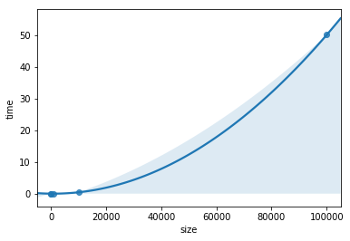

```python
sns.regplot(bubble_seg['size'],bubble_seg['time'],order=2)
```

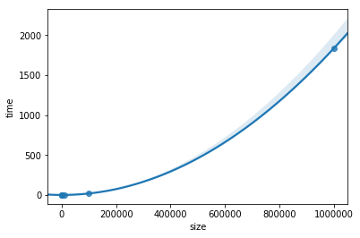

```python
sns.regplot(selection_seg['size'],selection_seg['time'],order=2)
```

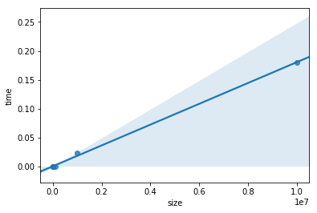

```python
sns.regplot(countsort_seg['size'],countsort_seg['time'])
```